# Track Assignment

Hallie Swan and Reid Shaw

4/2/2019

100 students rank 16 tracks from 1-16, where 1 is the most desired track. Each student is assigned to one track. Each track can hold 8 students. Some tracks are more popular than others. How do we optimize assignment of students to tracks, such that we minimize the total rank score (i.e. more students have lower rank scores and are in more highly desired tracks)?

Currently, Rochester iteratively selects a random student and assigns them to their highest rank track that is available (Or that is my best guess as to what they do). This can result in some students being assigned to poorly ranked tracks. Here, we explore whether solving the assignment problem using the Hungarian method results in overall minimized total rank score.

## Creating a Dataset of Randomized Rankings

We can generate a dataset containing randomly assigned ranks. We will weight the first four tracks more heavily to simulate the popularity of some tracks. The remaining tracks will be weighted evenly.

We can plot an example dataset to ensure that there is a good distribution of track ranking. A few rows of the dataset are shown below:

```
##     track    student rank
## 1 track01 student001    2
## 2 track02 student001    3
## 3 track03 student001    1
## 4 track04 student001   15
## 5 track05 student001    4
## 6 track06 student001    8
```

We plot the tracks by the number of students giving a certain rank. We see that the first four tracks have the highest ranks, but the remaining tracks have a good distribution of rankings.

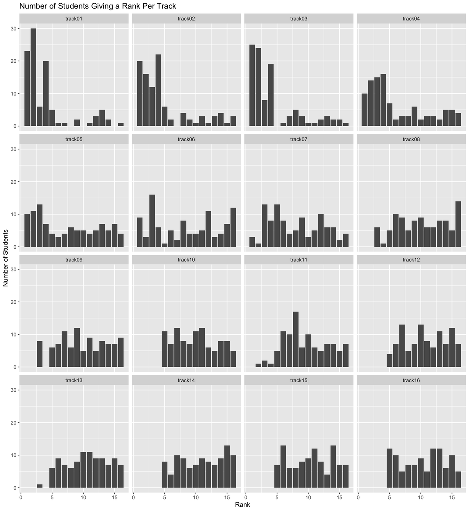

## Using the Rochester Method

We can then assign students to tracks using the Rochester method.

Using our example dataset, we look at the rankings of the tracks to which students were assigned using the Rochester method.

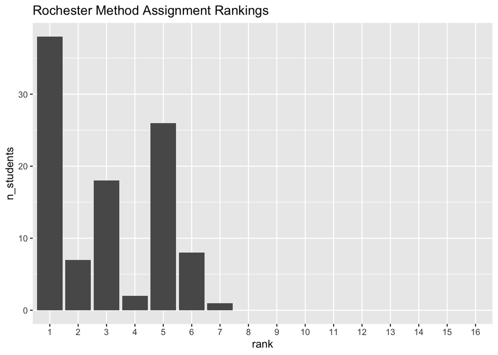

We see that most students were assigned to a track that they had ranked in the top half of tracks. We can think of the total “cost” of the assignment to be the sum of the rankings for each student. The total cost for this Rochester assignment is 299.

## Maximizing First Choices Method

This method is similar to Rochester method, but it always has the highest number of first choices

Here, we look at the rankings of the tracks to which students were assigned using the maximizing 1st choices method.

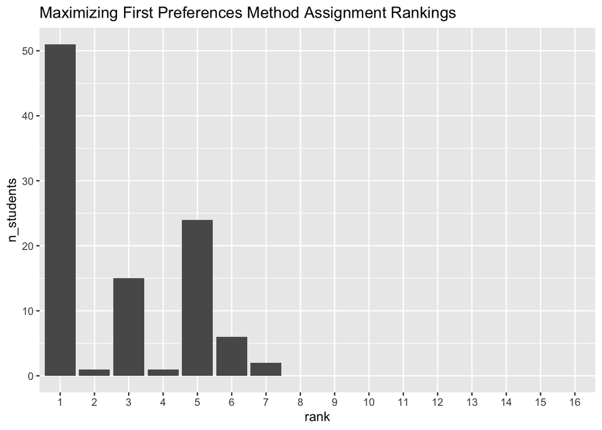

## Using the Hungarian Method

We can then assign students using the [Hungarian Method](http://www.hungarianalgorithm.com). We utilize the `solve_LSAP` function from the **clue** package to perform the algorithm. The Hungarian method also requires a square matrix of values, so we will create “dummy students” to fill out all available seats in each track. We will give each track the worst ranking so that these dummy students don’t affect the assignment of our real students.

Using the same example dataset, we look at the rankings of the tracks to which students were assigned using the Hungarian method.

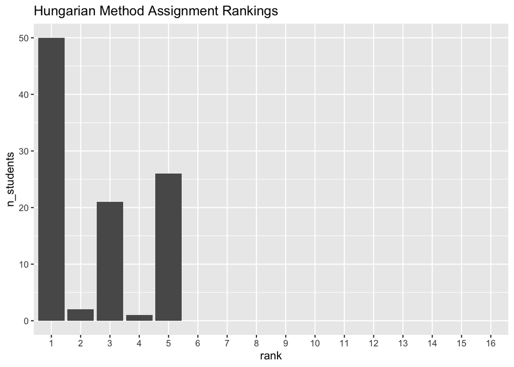

We see that more students were assigned to a higher priority track. The total cost for this Hungarian assignment is 251 (if everyone got their first choice the cost would be 100). This is lower than the Rochester method assignment cost.

## Iterate Methods

We can now compare the methods across many example simulated datasets to see if either method consistently returns a lower total assignment cost.

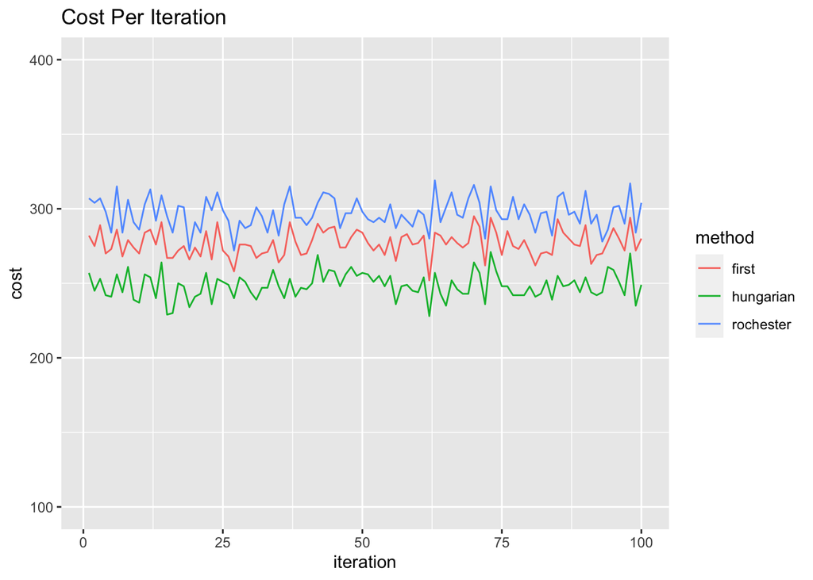

We can then plot the worst rank in each iteration.

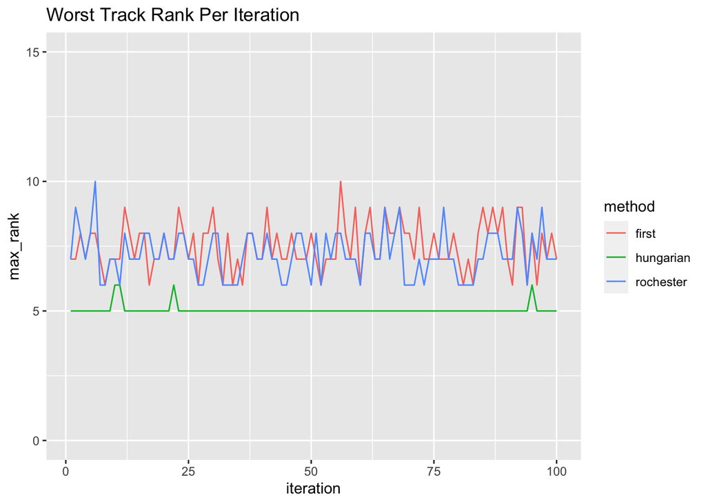

We can also plot the number of times a student got their first choice in each iteration.

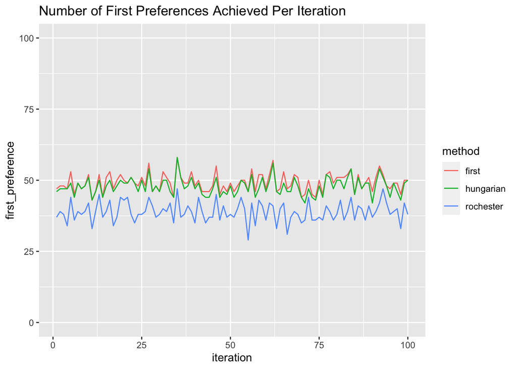

We see that in nearly all iterations, the Hungarian method has a lower cost, and lower worst rank. Unsurprisingly, iteratively assigning students to their top choice consistently has the highest number of first preferences achieved. The Rochester method is not the best in any of these categories. This means that the Hungarian method completes the assignment problem more effectively than the other two methods, especially the Rochester method.

## Summary

Based on this study, it appears that the Hungarian method is more effective at minimizing cost than the Rochester method. Therefore, the Hungarian method would better assign students to tracks than the Rochester method.